# Thunell DEBIPM Supporting info

Viktor Thunell

2021-03-18

## Supporting information for DEB IPM (for communication with coauthors)

### A1. Effects of size and temperature on maintenance, consumption and energy budget

#### Effects of temperature on maintenance and consumption

The quantitative effect of using a negative interaction term for consumption deactivation (cId) is the same as for using a positive interaction term for consumption activation (cIa).

I find the effect of activation (slope) for intake over size is more intuitive than decreasing deactivation and thus easier for communication purposes. I will therefore switch from using cId to using cIa.

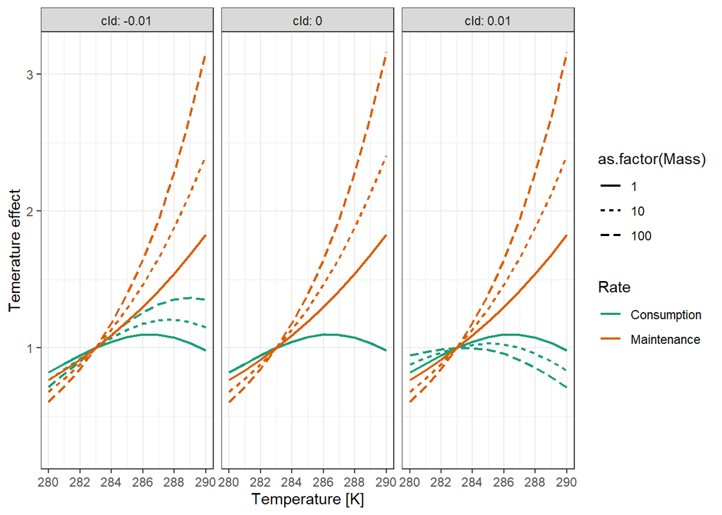

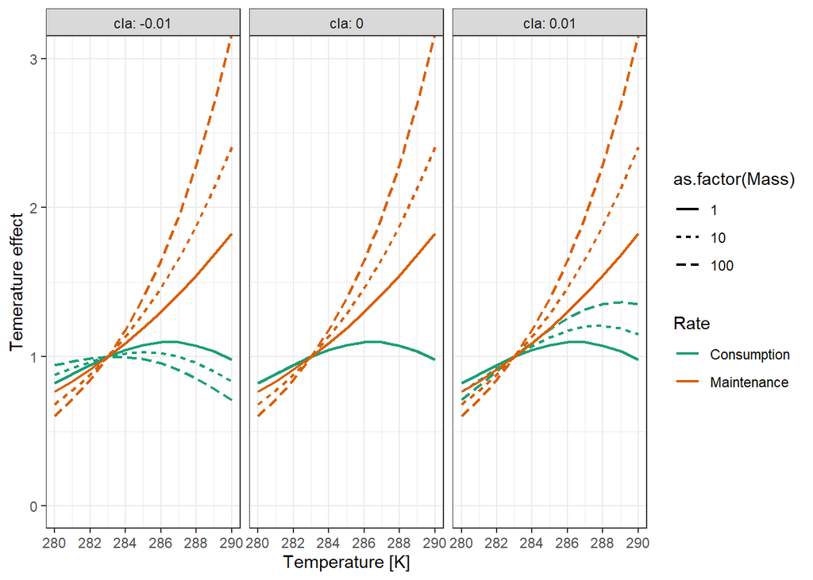

For a cId < 0, the effect of temperature on consumption deactivation will increase with increasing mass, meaning that for large individuals, the deactivation slope will be less negative than for small individuals. This moves the temperature optimum for consumption to higher temperatures. –>

For a cIa > 0, the effect of temperature on consumption (activation) will increase with increasing mass.

#### Effects of temperature on size dependent energy budget

A decrease in the interaction parameter for temperature deactivation over size, the slope between temperature and mass for consumption deactivation.

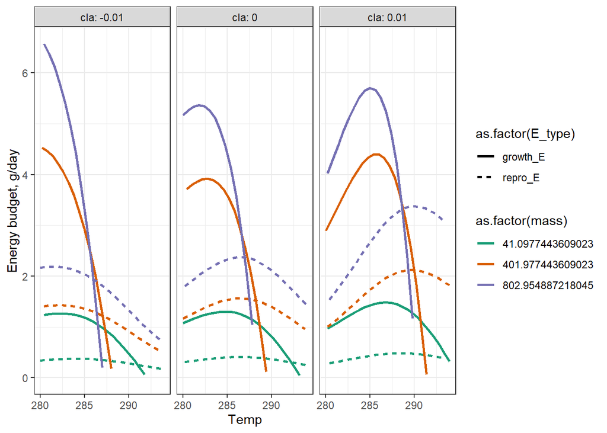

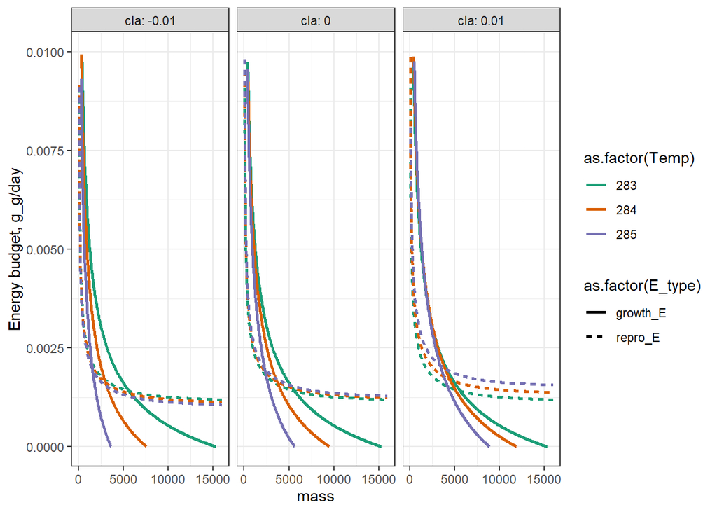

With an increasing cIa (or decreasing cId), the mass specific energy budget increases with temperature, enabling growth to larger sizes.

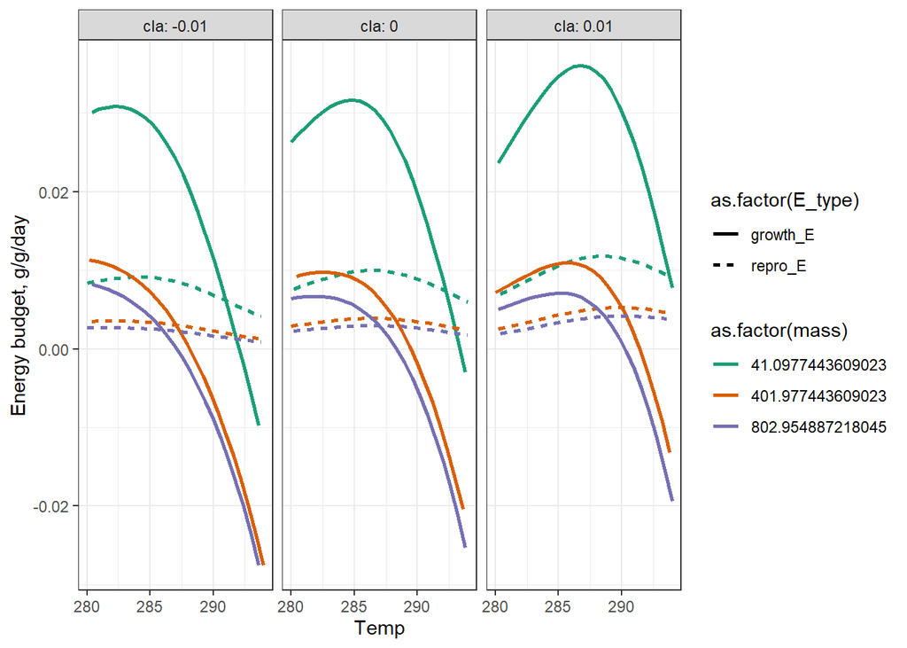

The mass specific temperature optimum for growth, i.e. the temperature at which the energy budget per unit mass is maximized, increases with cIa for both larger and small individuals. The effects is however stronger for larger individuals.

### Interaction on maintetance instead of intake

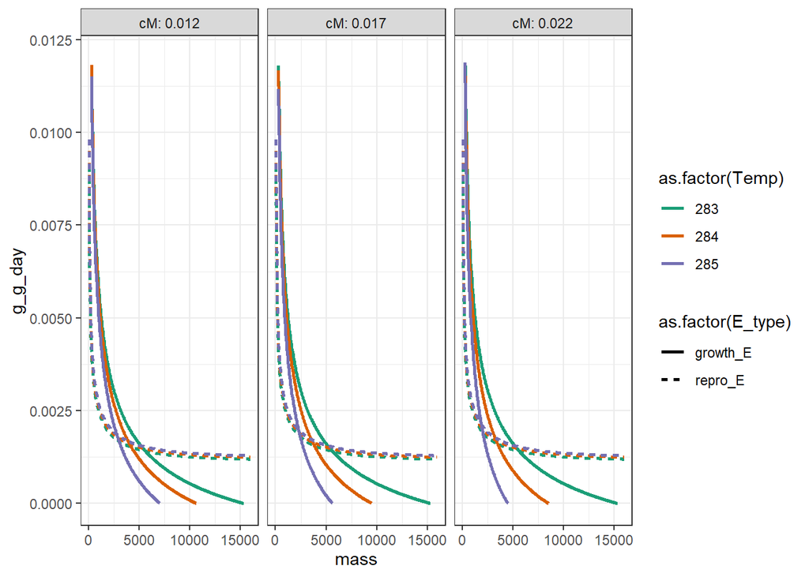

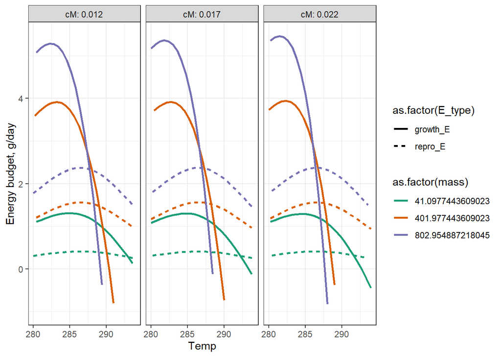

### Temperature dependent Growth curves

negative cId generates the same growth curves as a positve cIa

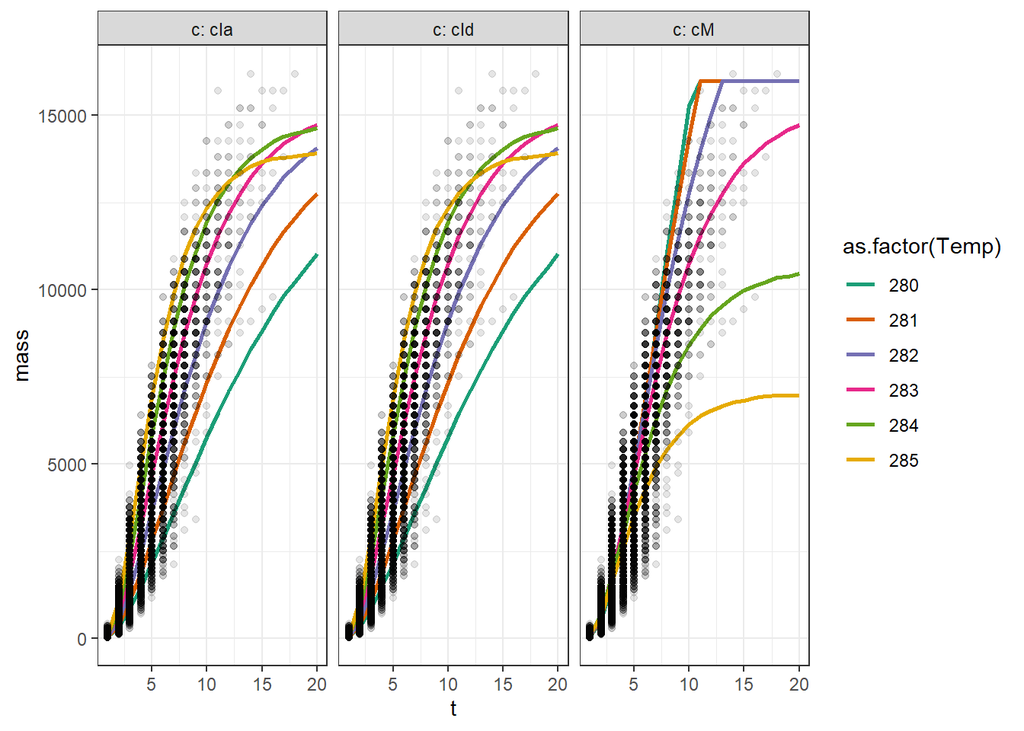